# Scooters

Yijia Liu, Xinyi Miao, Eugene Chong

February 13, 2020

# Admin

Define functions, directories, color palettes, inputs, etc here.

## Load packages

*List all packages here and include what we use them for.*

```r
library(sf)
library(measurements)
library(tidycensus)
library(tidyverse)
library(tmap)
library(lubridate)
library(knitr)
library(kableExtra)
library(rgeos)
library(raster)
library(spatstat)
library(data.table)
library(janitor)
library(vroom)
library(here)
library(dplyr)
library(sp)
library(viridis)
library(maptools)
library(stringr)
library(grid)
library(gridExtra)

options(tigris_use_cache = TRUE)
```

## Themes and Color Palettes

```r
# Palettes and Themes
paletteY <- c("#F9F871","#FFD364","#FFAF6D","#FF8F80","#F87895", "D16BA5")
palette5 <- c("#25CB10", "#5AB60C", "#8FA108","#C48C04", "#FA7800")

plotTheme <- theme(
  plot.title =element_text(size=15),
  plot.subtitle = element_text(size=8),
  plot.caption = element_text(size = 6),
  axis.text.x = element_text(size = 10, hjust = 1),
  axis.text.y = element_text(size = 10),
  axis.title.y = element_text(size = 10),
  # Set the entire chart region to blank
  panel.background=element_blank(),
  plot.background=element_blank(),
  #panel.border=element_rect(colour="#F0F0F0"),
  # Format the grid
  panel.grid.major=element_line(colour="#D0D0D0",size=.2),
  axis.ticks=element_blank())

mapTheme <- function(base_size = 12) {
  theme(
    text = element_text( color = "black"),
    plot.title = element_text(size = 14,colour = "black"),
    plot.subtitle=element_text(face="italic"),
    plot.caption=element_text(hjust=0),
    axis.ticks = element_blank(),
    panel.background = element_blank(),axis.title = element_blank(),
    axis.text = element_blank(),
    axis.title.x = element_blank(),
    axis.title.y = element_blank(),
    panel.grid.minor = element_blank(),
    panel.border = element_rect(colour = "black", fill=NA, size=2)
  )
}
```

## Helper Functions

- **qBr():** Find quintile breaks.
- **q5():** Find quintile breaks and set as factor.
- **rename_census_cols():** Rename census columns from ACS codes to variable names.

```r
qBr <- function(df, variable, rnd) {
  if (missing(rnd)) {
    as.character(quantile(round(df[[variable]],0),
                          c(.01,.2,.4,.6,.8), na.rm=T))
  } else if (rnd == FALSE | rnd == F) {
    as.character(formatC(quantile(df[[variable]]), digits = 3),
                 c(.01,.2,.4,.6,.8), na.rm=T)
  }
}

q5 <- function(variable) {as.factor(ntile(variable, 5))}

rename_census_cols <- function(x){

  output <- x %>%
    rename_at(vars(census_vars),
              ~ census_colNames)

  output
}
```

## Projections

List of projections to use for each city.

- Should we update MNP to a state plane?

```r
DC_proj <- 2283 # Northern Virginia: https://epsg.io/2283
LV_proj <- 2246 # https://www.spatialreference.org/ref/epsg/2246/
KC_proj <-2817 # https://spatialreference.org/ref/epsg/2817/
MNP_proj <- 26849 #https://www.spatialreference.org/ref/epsg/26849/
AU_proj <- 2246
```

## Census Variables

List of ACS variables we will collect for each city.

```r
census_df <- data.frame(vars =     c("B01003_001E",
                                     "B01001_026E",
                                     "B00002_001E",
                                     "B19013_001E",
                                     "B01002_001E",
                                     "B02001_002E",
                                     "B08014_001E",
                                     "B08014_002E",
                                     "B08013_001E",
                                     "B08012_001E",
                                     "B08012_008E",
                                     "B08012_009E",
                                     "B08012_010E",
                                     "B08012_011E",
                                     "B08012_012E",
                                     "B08012_013E",
                                     "B08301_001E",
                                     "B08301_002E",
                                     "B08301_010E",
                                     "B25002_001E",
                                     "B25002_002E",
                                     "B25077_001E",
                                     "B25064_001E"),

                        colNames = c("TotPop",
                                     "TotFemale",
                                     "TotHseUni",
                                     "MdHHInc",
                                     "MdAge",
                                     "White_Pop",
                                     "Vehicle_own_pop",
                                     "No_vehicle",
                                     "Total_Travel_Time",
                                     "Travel_Time_3034",
                                     "Travel_Time_3539",
                                     "Travel_Time_4044",
                                     "Travel_Time_4559",
                                     "Travel_Time_6089",
                                     "Travel_Time_90plus",
                                     "Num_Commuters",
                                     "Means_of_Transport_pop",
                                     "Total_cartruckvan",
                                     "Total_Public_Trans",
                                     "Total_occupancy",
                                     "Occupied",
                                     "MedValue",
                                     "MedRent"),
                        stringsAsFactors = FALSE)

census_vars <- census_df$vars
census_colNames <- census_df$colNames
```

# Louisville

## Read Data

Read in:

- **Louisville Base Map**
- **Louisville Scooter Service Area**
- **Scooter Datasets:**
  - Dockless Trips Open Data: User ride data listed on Louisville’s Open Data site.
  - Status Changes (Rebalance): Data from the scooter companies that (should) include the user ride data listed on the Open Data site plus any rebalancing or maintenance operations done on the scooters.
- **Census Information**

```r
# Read in base map
LV_base_map_raw <- st_read("https://opendata.arcgis.com/datasets/6e3dea8bd9cf49e6a764f7baa9141a95_30.geojson")

# Read in service area
LV_SA_file <- file.path(data_directory,
                        "Dockless Vehicle Service Area/Dockless_Vehicle_Service_Area.shp")

LV_SA_raw <- st_read(LV_SA_file)

# Read open data
LV_open_raw <- read_csv("https://data.louisvilleky.gov/sites/default/files/DocklessTripOpenData_9.csv")

# Read rebalance data
LV_rebal_file <- file.path(data_directory,
                           "/Louisville-MDS-Status-Changes-2019Dec17.csv")

LV_rebal_raw <- read_csv(LV_rebal_file)

# Census info
LV_Census_raw <- get_acs(geography = "tract",
                     variables = census_vars,
                     year = 2018,
                     state = "KY",
                     geometry = TRUE,
                     county = c("Jefferson"),
                     output = "wide") %>%
  rename_census_cols %>%
  dplyr::select(GEOID,
                geometry,
                census_colNames) %>%
  st_transform(LV_proj)

# Read in distribution areas
LV_distro_areas_file <- file.path(data_directory,
                             "Dockless Vehicle Distribution Zones v2/Dockless_Vehicle_Distribution_Zones.shp")

LV_distro_areas_raw <- st_read(LV_distro_areas_file)

LV_distro_areas <- LV_distro_areas_raw %>%
  mutate(Dist_Zone = as.character(Dist_Zone),
         # include the requirement for fleets between 350 and 1050. Currently the only requirements that apply
         rebal_req = case_when(Dist_Zone %in% c("1", "9") ~ 0.2,
                                 Dist_Zone == "8" ~ 0.1,
                                 TRUE ~ NA_real_)) %>%
  st_transform(LV_proj)
```

## Clean Data

- Project data
- Rebalance Data
  - Make *sf* object
  - Correct typos
  - Initialize `operators` and `duration` columns
  - Filter for service area
- Open Data: Define helper function for making *sf* objects with either the trip start or trip end
- Census
  - Make census columns
  - Extract centroids

```r
# Project Base Map
LV_base_map <- LV_base_map_raw %>%
  st_transform(LV_proj)

# Project Service Area Map
LV_SA <- LV_SA_raw %>%
  st_transform(LV_proj)

### Make rebalance sf object ----
# Make the object with the code below ('ctrl + shift + c' to un-comment multiple lines at once)

LV_rebal_sf <- st_as_sf(LV_rebal_raw,
                            wkt = "location",
                            crs = 4326) %>%
  st_transform(LV_proj) %>%
  mutate(operators = ifelse(operators == "Bolt Lousiville", # fix typo
                            "Bolt Louisville",
                            operators),
         operators = as.factor(operators),
         duration = 0, # initialize columns for for-loop
         energy_diff = 0) %>%
  .[LV_SA,] # filter out any trips outside the service area

LV_rebal_sf_RDS <- file.path(data_directory,
                             "~RData/Louisville/LV_rebal_sf")
#
# saveRDS(LV_rebal_sf,
#         file = LV_rebal_sf_RDS)

# Read the saved object with the code below
# LV_rebal_sf <- readRDS(LV_rebal_sf_RDS)

# Make sf objects with open data ----
make_LV_open_sf <- function(x, # x should be 'LV_open_raw'
                            trip_end, # define whether you want the origins or the destinations
                            proj) { # proj should be 'LV_proj'

  if(!grepl("ori|des", trip_end)) {

    stop("trip_end must be either 'origins' or 'dests'")

  } else if (grepl("ori", trip_end)) {

    output <- x %>%
      dplyr::select(TripID,
                    StartLatitude,
                    StartLongitude) %>%
      st_as_sf(coords = c("StartLongitude", "StartLatitude"),
               crs = 4326) %>%
      st_transform(proj)

  } else {

    output <- x %>%
      dplyr::select(TripID,
                    EndLatitude,
                    EndLongitude) %>%
      st_as_sf(coords = c("EndLongitude", "EndLatitude"),
               crs = 4326) %>%
      st_transform(proj)

  }
  output
}
```

## Rebalance Data

The Rebalance Data is a dataset that lists every “status change” for every scooter operated in Louisville between November 2018 and December 2019.

Each row is a trip end. *E.g.* one row is a pickup at a certain location, and the next row is the dropoff, though the data is not always so clean, and events that should be paired do not have a corresponding entry.

### User Events

- Limit data to “user” events, *i.e.* riders picking up and dropping off a scooter.
- Define helper functions:
  - calc_tripDuration_and_energy(): Calculate duration of trips and energy used.
  - combine_rowPairs(): Transform dataset so each row is a trip.

```r
# Filter for user events, sort, and add duration and energy_diff columns
LV_rebal_user_only <- LV_rebal_sf %>%
  filter(str_detect(reason, "user"))%>%
  arrange(vehicleId, occurredAt) # sort by vehicle ID and time

### Helper Functions
# Define function for calcuating trip durations and energy levels ----
calc_tripDuration_and_energy <- function(x) {

  output <- list() # initialize list

  for (veh in unique(x$vehicleId)) { # for each unique vehicle
    this_vehicle_set <- x %>% filter(vehicleId == veh) # filter for that vehicle
    print(veh) # print so we can see the progress of the loop

    for (i in 1:nrow(this_vehicle_set)) { # for each row of this vehicle
      if (i%%2 == 1) { # if this is an odd number row

        # the trip duration is the time for the next row minus the time for this row
        this_vehicle_set$duration[i] <- difftime(this_vehicle_set$occurredAt[i+1], this_vehicle_set$occurredAt[i], units = 'mins')

        # same with energy level
        this_vehicle_set$energy_diff[i] <- this_vehicle_set$vehicleEnergyLevel[i+1]- this_vehicle_set$vehicleEnergyLevel[i]
        } else {}
    }
    output[[veh]] <- this_vehicle_set
  }

  as.data.frame(data.table::rbindlist(output,
                                      idcol = "vehicleId"))

}

# One with a start and end time and start and end location ----
combine_rowPairs <- function(x) { # x should be the output of calc_tripDuration_and_energy()

  temp <- data.frame("vehicleID" = c(0), # initialize temp dataframe with columns
                     "start_time" = c(0),
                     "end_time" = c(0),
                     "trip_origin" = c(0),
                     "trip_dest" = c(0),
                     "duration" = c(0),
                     "energy_diff" = c(0))

  output <- list() # initialize output list

  for (i in seq(nrow(x) - 1)) {
    # need to do minus 1 b/c if there is an odd number of rows, the last row of the trip_dest column will be empty
    # and cannot be binded with the other rows
    if (i%%2 == 1) {

      print(i)

      temp$vehicleID = x$vehicleId[i]
      temp$start_time = x$occurredAt[i]
      temp$end_time = x$occurredAt[i+1]
      temp$trip_origin = x$location[i]
      temp$trip_dest = x$location[i+1]
      temp$duration = x$duration[i]
      temp$energy_diff = x$energy_diff[i]

      output[[i]] <- temp

    } else {}
  }

  output <- as.data.frame(data.table::rbindlist(output))

}

LV_rebal_user_only_combined_rowPairs <- LV_rebal_user_only %>%
  calc_tripDuration_and_energy() %>%
  combine_rowPairs()

# June 2019 ----
LV_rebal_user_only_0619 <- LV_rebal_user_only %>%
  filter(year(occurredAt) == 2019, month(occurredAt) == 6)

LV_rebal_user_only_0619_combined_rowPairs <- LV_rebal_user_only_0619 %>%
  calc_tripDuration_and_energy()

LV_rebal_user_only_0619_combined_rowPairs <- LV_rebal_user_only_0619_combined_rowPairs %>%
  combine_rowPairs()

LV_rebal_user_only_combined_rowPairs_RDS <- file.path(data_directory,
                                                      "~RData/Louisville/LV_rebal_user_only_combined_rowPairs")

# saveRDS(LV_rebal_user_only_combined_rowPairs,
#         file = LV_rebal_user_only_combined_rowPairs_RDS)

LV_rebal_user_only_0619_combined_rowPairs_RDS <- file.path(data_directory,
                                                      "~RData/Louisville/LV_rebal_user_only_0619_combined_rowPairs")

# saveRDS(LV_rebal_user_only_0619_combined_rowPairs,
#         file = LV_rebal_user_only_0619_combined_rowPairs_RDS)

# Read the saved object with the code below
# LV_rebal_user_only_combined_rowPairs <- readRDS(LV_rebal_user_only_combined_rowPairs_RDS)
# LV_rebal_user_only_0619_combined_rowPairs <- readRDS(LV_rebal_user_only_0619_combined_rowPairs_RDS)
```

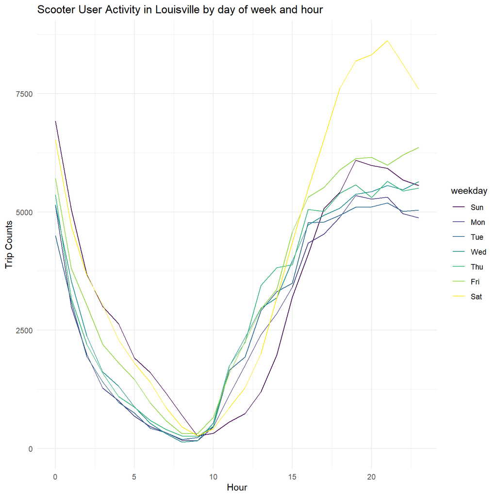

```r
LV_user_DOW_data <- LV_rebal_user_only %>%
  mutate(hour = hour(occurredAt),
         weekday = lubridate::wday(occurredAt, label = TRUE))

LV_user_DOW_data %>%
  ggplot() +
  geom_freqpoly(aes(hour, color = weekday), binwidth = 1) +
  labs(title = "Scooter User Activity in Louisville by day of week and hour",
       x="Hour",
       y="Trip Counts")+
  xlim(0, 23)+
  theme_minimal()
```

### Rebalance Events

- Limit data to “rebalance” events
- Loops:
  - Remove “duplicated” events. Sometimes there will be consecutive pick up events for a single vehicle.
  - calc_tripDuration_and_energy(): Calculate duration of trips and energy used.
  - combine_rowPairs(): Transform dataset so each row is a trip.

```r
# Filter for rebalance events, sort, and add duration and energy_diff columns
LV_rebal_rebalance_only <- LV_rebal_sf %>%
  filter(str_detect(reason, "rebalance"))%>%
  arrange(vehicleId, occurredAt) # sort by vehicle ID and time

# Trim the dataset to be "pick-up; drop-off" format b/c sometimes there is [reb pick up, reb pick up, reb drop off]
LV_reb_ID_list <- c()
for (veh in unique(LV_rebal_rebalance_only$vehicleId)) {
  this_vehicle_set <- LV_rebal_rebalance_only %>% filter(vehicleId == veh)
  print(veh)
  output_list <- c() # initialize list
  for (i in 1:nrow(this_vehicle_set)) {
      if (this_vehicle_set$reason[i] == 'rebalance drop off') {
        output_list <- append(output_list, c(this_vehicle_set$id[i], this_vehicle_set$id[i-1])) #store the id of rebalance drop off and rebalance pick up before it
  }}
    LV_reb_ID_list <- append(LV_reb_ID_list, output_list) #this should store all the [pick-up, drop-off] pairs
  }


LV_rebal_rebalance_only_trim1 <- LV_rebal_rebalance_only %>%
  filter(LV_rebal_rebalance_only$id %in% LV_reb_ID_list) # Trim the data set

# Notice the dataset has some weird [pick-up, drop-off, drop-off] and some of them does not have [pick-up] info at all
# We trim the dataset one more time by the other way round
LV_reb_ID_list2 <- c()
for (veh in unique(LV_rebal_rebalance_only_trim1$vehicleId)) {
  this_vehicle_set <- LV_rebal_rebalance_only_trim1 %>% filter(vehicleId == veh)
  print(veh)
  output_list <- c() # initialize list
  for (i in 1:nrow(this_vehicle_set)) {
    if (this_vehicle_set$reason[i] == 'rebalance pick up') {
      output_list <- append(output_list, c(this_vehicle_set$id[i], this_vehicle_set$id[i+1])) #store the id of rebalance drop off and rebalance pick up before it
    }}
  LV_reb_ID_list2 <- append(LV_reb_ID_list2, output_list) #this should store all the [pick-up, drop-off] pairs
}

# This should be our final dataset to use to generate trip origin-destination table
LV_rebal_rebalance_only_trim2 <- LV_rebal_rebalance_only_trim1 %>%
  filter(LV_rebal_rebalance_only_trim1$id %in% LV_reb_ID_list2)

LV_rebal_reb_only_combined_rowPairs <- LV_rebal_rebalance_only_trim2 %>%
  calc_tripDuration_and_energy()

LV_rebal_reb_only_combined_rowPairs <- LV_rebal_reb_only_combined_rowPairs%>%
  combine_rowPairs()

# June 2019 ----
LV_rebal_reb_only_0619_combined_rowPairs  <- LV_rebal_reb_only_combined_rowPairs %>%
  filter(year(start_time) == 2019) %>%
  filter(month(start_time) == 6 |month(end_time) == 6)

# Save & Load
LV_rebal_reb_only_combined_rowPairs_RDS <- file.path(data_directory,
                                                      "~RData/Louisville/LV_rebal_reb_only_combined_rowPairs")

LV_rebal_reb_only_0619_combined_rowPairs_RDS <- file.path(data_directory,
                                                     "~RData/Louisville/LV_rebal_reb_only_0619_combined_rowPairs")

# saveRDS(LV_rebal_reb_only_0619_combined_rowPairs,
#                 file = LV_rebal_reb_only_0619_combined_rowPairs_RDS)
# saveRDS(LV_rebal_reb_only_combined_rowPairs,
#         file = LV_rebal_reb_only_combined_rowPairs_RDS)

# Read the saved object with the code below
# LV_rebal_reb_only_combined_rowPairs <- readRDS(LV_rebal_reb_only_combined_rowPairs_RDS)
# LV_rebal_reb_only_0619_combined_rowPairs <- readRDS(LV_rebal_reb_only_0619_combined_rowPairs_RDS)
```

Rebalancing activity primarily occurs in the early morning and late night hours.

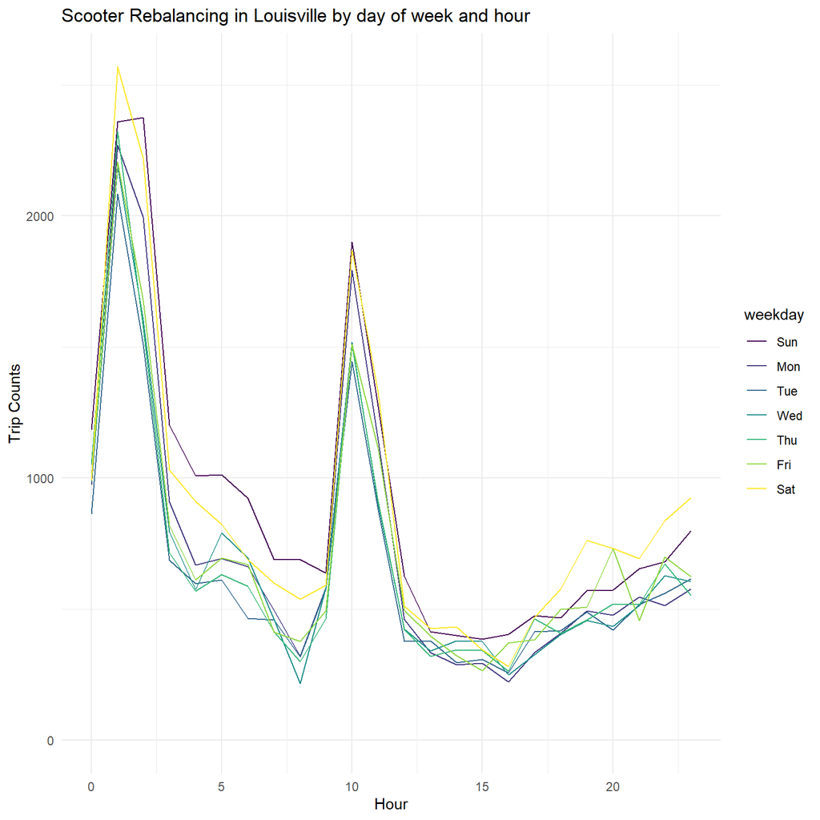

```r
LV_rebal_DOW_data <- LV_rebal_rebalance_only %>%
  mutate(hour = hour(occurredAt),
         weekday = lubridate::wday(occurredAt, label = TRUE))

LV_rebal_DOW_data %>%
  ggplot() +
  geom_freqpoly(aes(hour, color = weekday), binwidth = 1) +
  labs(title = "Scooter Rebalancing in Louisville by day of week and hour",
       x="Hour",
       y="Trip Counts")+
  xlim(0, 23)+
  theme_minimal()
```

The flow maps below show the census tracts with the highest inflow of scooters from rebalancing.

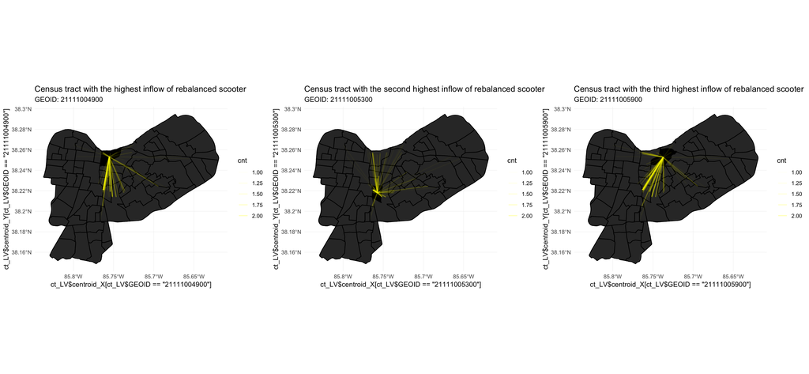

Rebalance inflow

### Are scooter providers complying with rebalancing policy?

With the goal of promoting equity of transportation access, the City of Louisville requires scooter providers operating more than a certain number of vehicles to distribute a percentage of those vehicles to particular zones. Per the city’s dockless vehicle policy:

> Distribution zones are intended to ensure that no singular zone is intentionally over-served or under-served.

For operators with more than 150 vehicles, 20% of vehicles must be in zones 1 and 9. For operators with more than 350 vehicles, an additional 10% of scooters must be in zone 8.

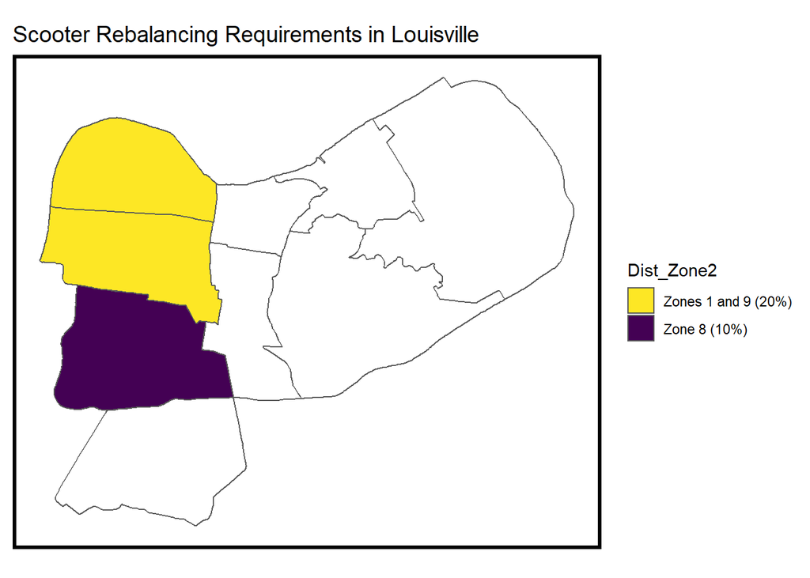

```r
LV_distro_areas_map <- LV_distro_areas %>%
  mutate(Dist_Zone2 = case_when(Dist_Zone %in% c(1, 9) ~ "Zones 1 and 9 (20%)",
                                Dist_Zone == 8 ~ "Zone 8 (10%)",
                                TRUE ~ NA_character_))

ggplot() +
  geom_sf(data = LV_distro_areas_map, aes(fill = Dist_Zone2)) +
  scale_fill_viridis_d(limits = c("Zones 1 and 9 (20%)", "Zone 8 (10%)"),
                       direction = -1,
                       na.translate = FALSE) +
  mapTheme() +
  labs(title = "Scooter Rebalancing Requirements in Louisville")
```

Currently, Bird and Lime are the only operators permitted to operate more than 150 scooters in Louisville, with each having a limit of 450. However, this doesn’t necessarily mean they are deploying fleets up to the full limit.

While the Rebalance Data tell us about vehicle flows – what vehicles have entered and exited the system and where are they moving – they don’t at first glance tell us about the status of the entire fleet. That a vehicle hasn’t moved in a while and doesn’t appear in the Rebalance Data on a particular day doesn’t mean it’s not somewhere in the city ready to be ridden.

However, by tracking the most recent status of each vehicle at any given time, we can get a snapshot at any point in time with the locations of every available scooter in Louisville.

Process: 1. Assign an `active`, `reserved`, and `inactive` status for every event type. 2. Find a time interval to audit. For this vignette, we look at noon at mid-month for every month from the beginning of scooter service in Louisville (November 2018) to December 2019. 3. For each vehicle in the dataset (determined by unique `vehicleId`), find its most recent status at each audit time. * If the scooter’s status is `active`, return its location. * Set a `buffer` time. If the scooter hasn’t had a status change in the last 10 days, consider it `inactive` and removed from the fleet. 4. For every active scooter, determine which distribution zone it’s located in. 5. Summarize the vehicles by distribution zone and operator to see who is complying with the rebalancing requirements.

```r
LV_active_status <- c("user drop off",
                      "rebalance drop off",
                      "maintenance drop off",
                      "service start")

LV_reserved_status <- c("user pick up")

LV_inactive_status <- c("rebalance pick up",
                        "maintenance pick up",
                        "service end",
                        "low battery",
                        "maintenance")

# Function for finding the last status for every scooter
LV_extract_latest_status <- function(x, # list of scooter dataframes
                                     datetime, # format = "YYYY-MM-DD HH:MM"
                                     # hour, # format = "HH:MM" in 24 hour time
                                     buffer # of days since last activity that we're willing to consider a scooter still active.
){

  time <- as.POSIXct(datetime)

  tmp <-  x %>%
    as.data.frame() %>%
    dplyr::select(vehicleId, occurredAt, reason, operators, location, long, lat) %>%
    filter(occurredAt <= time) %>% # can we replace this with the buffer call below?
    arrange(occurredAt) %>%
    tail(1) %>%
    filter(as.numeric(time - occurredAt) <= buffer,
           reason %in% LV_active_status)

  if(nrow(tmp) > 0) {
    output <- tmp %>%
      mutate(Date = as.Date(occurredAt),
             Hour = hour(occurredAt),
             active = 1) %>%
      dplyr::select(vehicleId, Date, Hour, operators, active, long, lat)

  } else {

    output <- data.frame(vehicleId = x$vehicleId[1],
                         Date = as.Date(time),
                         Hour = hour(time),
                         operators = x$operators[1],
                         active = 0,
                         long = NA_real_,
                         lat = NA_real_,
                         stringsAsFactors = FALSE)
  }

  # output <- data.frame(Date = as.Date(time),
  #                      Hour = hour(time),
  #                      vehicleId = df$vehicleId[1],
  #                      operators = df$vehicleId[1],
  #                      location = ifelse(nrow(tmp) > 0, tmp$location[1], NA),
  #                      active = ifelse(nrow(tmp) > 0, 1, 0),
  #                      stringsAsFactors = FALSE)

  output

}

# Find latest status for every scooter
time_intervals <- seq(from = as.POSIXct("2018-11-15 12:00:00 EDT"),
                      to = as.POSIXct("2019-12-15 12:00:00 EDT"),
                      by = "1 month")

# loop over dates
LV_rebal_sf_list <- map(time_intervals,
                        function(x){LV_rebal_sf %>%
  mutate(long = st_coordinates(.)[,1],
         lat = st_coordinates(.)[,2]) %>%
  as.data.frame() %>%
  split(.$vehicleId) %>%
  map(.,
      function(y){LV_extract_latest_status(y,
                                           datetime = x,
                                           # hour = "12:00",
                                           buffer = 10)}) %>%
    bind_rows() %>%
    mutate(audit_date = x)}) %>%
  bind_rows()

# Add region for every active scooter
LV_rebal_sf_list_2 <- LV_rebal_sf_list %>%
  filter(!is.na(long),
         !is.na(lat)) %>%
  st_as_sf(coords = c("long", "lat"), crs = LV_proj, remove = FALSE) %>%
  st_join(., LV_distro_areas %>% dplyr::select(Dist_Zone)) %>%
  st_drop_geometry() %>%
  mutate(Dist_Zone = factor(Dist_Zone,
                            levels = paste(1:9)))

LV_rebal_sf_list_summary <- LV_rebal_sf_list %>%
  left_join(LV_rebal_sf_list_2 %>% dplyr::select(vehicleId, Dist_Zone, audit_date), by = c("vehicleId", "audit_date")) %>%
  group_by(audit_date, Dist_Zone, operators, .drop = FALSE) %>%
  summarize(scooters = n()) %>%
  filter(str_detect(operators, "Bird|Lime"),
         !is.na(Dist_Zone)) %>%
  ungroup() %>%
  group_by(audit_date, operators) %>%
  mutate(scooter_total = sum(scooters),
         scooter_pct = scooters / scooter_total)

LV_rebal_sf_list_summary_2 <- LV_rebal_sf_list_summary %>%
  dplyr::select(-scooter_pct) %>%
  spread(Dist_Zone, scooters, sep = "_") %>%
  mutate(Dist_8_pct = ifelse(is.na(Dist_Zone_8 / scooter_total), 0, Dist_Zone_8 / scooter_total),
         Dist_1_9_pct = ifelse(is.na((Dist_Zone_1 + Dist_Zone_9) / scooter_total), 0, (Dist_Zone_1 + Dist_Zone_9) / scooter_total),
         compliance = case_when(scooter_total > 150 & Dist_1_9_pct < 0.2 ~ "No",
                                scooter_total > 350 & (Dist_1_9_pct < 0.2 | Dist_8_pct < 0.1) ~ "No",
                                TRUE ~ "Yes"))
```

Generally, Bird and Lime do not comply with the requirements. The percentage of available scooters in Zones 1, 8, and 9 are much lower than the threshold.

**Internal Note:** Need to account for how vehicle fleet fluctuates according to our metric. If “active” fleet is less than 350 at a given time, Zone 8 requirement doesn’t apply.

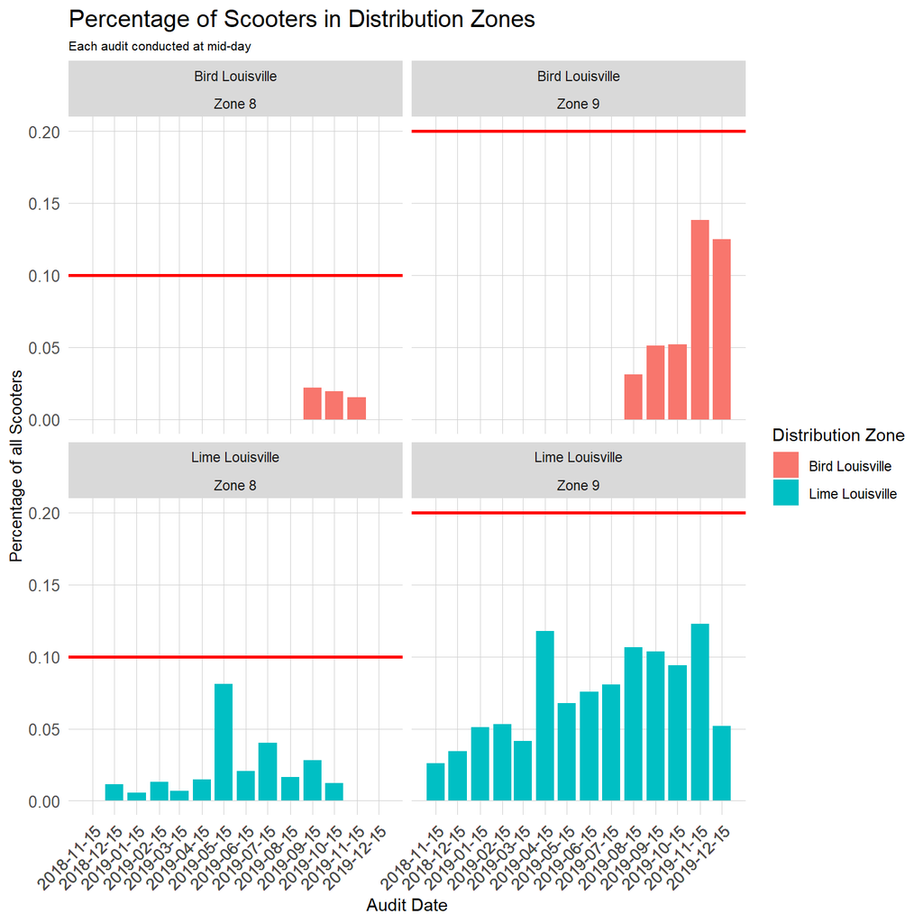

```r
LV_rebal_sf_list_summary_2_map <- LV_rebal_sf_list_summary_2 %>%
  gather(dist_zone, dist_pct, Dist_8_pct:Dist_1_9_pct) %>%
  mutate(requirement = case_when(dist_zone == "Dist_8_pct" ~ 0.1,
                                 dist_zone == "Dist_1_9_pct" ~ 0.2,
                                 TRUE ~ NA_real_),
         dist_zone = factor(case_when(dist_zone == "Dist_8_pct" ~ "Dist_8_pct",
                                      dist_zone == "Dist_1_9_pct" ~ "Dist_1_9_pct",
                                      TRUE ~ NA_character_),
                            levels = c("Dist_8_pct", "Dist_1_9_pct"),
                            labels = c("Zone 8", "Zone 9")))

ggplot(LV_rebal_sf_list_summary_2_map,
       aes(x = audit_date,
           y = dist_pct,
           fill = operators)) +
  geom_bar(stat = "identity",
           position = "dodge") +
  geom_hline(data = LV_rebal_sf_list_summary_2_map,
             aes(yintercept = requirement),
             color = "red",
             size = 1) +
  facet_wrap(operators~dist_zone) +
  plotTheme +
  labs(title = "Percentage of Scooters in Distribution Zones",
       subtitle = "Each audit conducted at mid-day",
       y = "Percentage of all Scooters",
       x = "Audit Date")  +
  scale_x_datetime(date_labels = "%Y-%m-%d",
                   breaks = LV_rebal_sf_list_summary_2_map$audit_date) +
  scale_fill_discrete(name = "Distribution Zone") +
  theme(axis.text.x = element_text(angle = 45, hjust = 1))
```

If we map the locations of active scooters on November 15, 2019, we’ll see that few of them are located in the required distribution zones.

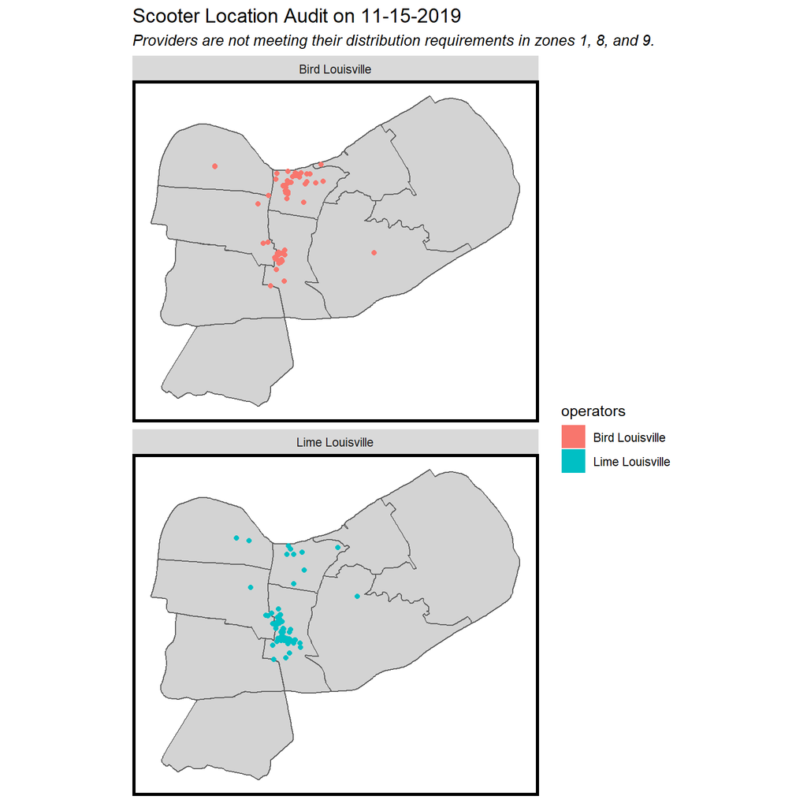

```r
LV_audit_map <- LV_rebal_sf_list_2 %>%
  filter(audit_date == as.POSIXct("2019-11-15 12:00:00 EST")) %>%
  st_as_sf(coords = c("long", "lat"), crs = LV_proj)

ggplot() +
  geom_sf(data = LV_distro_areas, fill = "lightgray") +
  geom_sf(data = LV_audit_map %>% filter(str_detect(operators, "Lime|Bird")),
          aes(color = operators, fill = operators)) +
  facet_wrap(~operators, ncol = 1) +
  mapTheme() +
  labs(title = "Scooter Location Audit on 11-15-2019",
       subtitle = "Providers are not meeting their distribution requirements in zones 1, 8, and 9.")
```

## Opportunity Index

```r
# rebalancing data####
# structured rebalance data (i.e. LV_rebal_reb_only_0619_combined_rowPairs here) could be obtained by running code LV - 04.
# obtain fields about longitude and latitude.
LV_rebal_reb_only_0619_combined_rowPairs <- LV_rebal_reb_only_0619_combined_rowPairs %>%
  mutate(week = week(end_time)) %>%
  st_as_sf(sf_column_name = "trip_origin", crs = LV_proj) %>%
  mutate(lon_s = st_coordinates(.)[1],
         lat_s = st_coordinates(.)[2]) %>%
  as.data.frame() %>%
  st_as_sf(sf_column_name = "trip_dest", crs = LV_proj) %>%
  mutate(lon_d = st_coordinates(.)[1],
         lat_d = st_coordinates(.)[2]) %>%
  as.data.frame()

# then, we want to know which census tract did these trips ended in.
LV_rebal_reb_only_0619_combined_rowPairs_sf_end <- st_as_sf(LV_rebal_reb_only_0619_combined_rowPairs,
                                                        sf_column_name = "trip_dest", crs = LV_proj)

LV_rebal_reb_only_0619_combined_rowPairs_ct_end <- st_join(LV_rebal_reb_only_0619_combined_rowPairs_sf_end,
                                                       LV_Census_geoinfo %>%
                                                         dplyr::select(GEOID), st_within, left=T) %>%
  rename(End.Census.Tract = GEOID)

LV_rebal_reb_only_0619_combined_rowPairs_sf_start <- st_as_sf(LV_rebal_reb_only_0619_combined_rowPairs,
                                                            sf_column_name = "trip_origin", crs = LV_proj)

LV_rebal_reb_only_0619_combined_rowPairs_ct_start <- st_join(LV_rebal_reb_only_0619_combined_rowPairs_sf_start,
                                                           LV_Census_geoinfo %>%
                                                             dplyr::select(GEOID), st_within, left=T) %>%
  rename(Start.Census.Tract = GEOID)

### calculating the opportunity index (rebalancing drop off and trips end) for each census tract by week
# first we focus on rebalancing drop off and pickup data
LV_reb_dropoff_ct <- LV_rebal_reb_only_0619_combined_rowPairs_ct_end %>%
  na.omit() %>%
  group_by(week, End.Census.Tract) %>%
  summarise(cnt_reb = n())

LV_reb_pickup_ct <- LV_rebal_reb_only_0619_combined_rowPairs_ct_start %>%
  na.omit() %>%
  group_by(week, Start.Census.Tract) %>%
  summarise(cnt_reb = n())

# users data ####
# LV_rebal_user_only_0619_combined_rowPairs could be obtained by running code LV - 03
# next, we turn to the user trips data
LV_rebal_user_only_0619_combined_rowPairs <- LV_rebal_user_only_0619_combined_rowPairs %>%
  mutate(week = week(end_time)) %>%
  st_as_sf(sf_column_name = "trip_origin", crs = LV_proj) %>%
  mutate(lon_s = st_coordinates(.)[1],
         lat_s = st_coordinates(.)[2]) %>%
  as.data.frame() %>%
  st_as_sf(sf_column_name = "trip_dest", crs = LV_proj) %>%
  mutate(lon_d = st_coordinates(.)[1],
         lat_d = st_coordinates(.)[2]) %>%
  as.data.frame()

LV_rebal_user_only_0619_combined_rowPairs_sf_end <- st_as_sf(LV_rebal_user_only_0619_combined_rowPairs,
                                                         sf_column_name = "trip_dest", crs = LV_proj)

LV_rebal_user_only_0619_combined_rowPairs_ct_end <- st_join(LV_rebal_user_only_0619_combined_rowPairs_sf_end,
                                                        LV_Census_geoinfo %>%
                                                          dplyr::select(GEOID), st_within, left=T) %>%
  rename(End.Census.Tract = GEOID)

LV_rebal_user_only_0619_combined_rowPairs_sf_start <- st_as_sf(LV_rebal_user_only_0619_combined_rowPairs,
                                                             sf_column_name = "trip_origin", crs = LV_proj)

LV_rebal_user_only_0619_combined_rowPairs_ct_start <- st_join(LV_rebal_user_only_0619_combined_rowPairs_sf_start,
                                                            LV_Census_geoinfo %>%
                                                              dplyr::select(GEOID), st_within, left=T) %>%
  rename(Start.Census.Tract = GEOID)


# first we focus on rebalancing drop off data
LV_users_dropoff_ct <- LV_rebal_user_only_0619_combined_rowPairs_ct_end %>%
  na.omit() %>%
  group_by(week, End.Census.Tract) %>%
  summarise(cnt_user = n())

LV_users_pickup_ct <- LV_rebal_user_only_0619_combined_rowPairs_ct_start %>%
  na.omit() %>%
  group_by(week, Start.Census.Tract) %>%
  summarise(cnt_user = n())


### Create a panel ####
# rebalance_june contains all the trips (including rebalancing and users' etc.) happened in June, 2019
LV_rebal_sf_0619 <- LV_rebal_sf  %>%
  filter(year(occurredAt) == 2019, month(occurredAt) == 6) %>%
  mutate(week = week(occurredAt))

LV_study.panel <-
  expand.grid(week = unique(LV_rebal_sf_0619$week),
              End.Census.Tract = unique(LV_Census_geoinfo$GEOID)) %>%
  mutate(End.Census.Tract = as.character(End.Census.Tract)) %>%
  left_join(., LV_reb_dropoff_ct %>% st_set_geometry(NULL), how = 'left', by = c("week", "End.Census.Tract")) %>%
  left_join(., LV_users_dropoff_ct %>% st_set_geometry(NULL), how = 'left', by = c("week", "End.Census.Tract")) %>%
  mutate(cnt_reb = replace_na(cnt_reb, 0),
         cnt_user = replace_na(cnt_user, 0),
         OI = cnt_reb + cnt_user)

# now lets focus on the trips started from each census tract
LV_users_pickup_ct <- LV_rebal_user_only_0619_combined_rowPairs_ct_start %>%
  na.omit() %>%
  group_by(week, Start.Census.Tract) %>%
  summarise(cnt_out = n()) %>%
  rename(End.Census.Tract = Start.Census.Tract)

LV_study.panel <- left_join(LV_study.panel, LV_users_pickup_ct %>% st_set_geometry(NULL), how='left', by = c("week", "End.Census.Tract")) %>%
  mutate(cnt_out = replace_na(cnt_out, 0),
         diff = OI - cnt_out)

### weekly opportunity index in June
LV_OI_bymonth <- LV_study.panel %>%
  group_by(End.Census.Tract) %>%
  summarise(mean_OI = mean(OI), mean_out = mean(cnt_out)) %>%
  mutate(diff = mean_OI - mean_out) %>%
  left_join(LV_Census_geoinfo, by = c('End.Census.Tract' = 'GEOID'))
```

### Maps

#### Opportunity Index

Another way we’ve conceptualized equity of access to scooters is through an Opportunity Index. We define the OI as:

`Opportunity Index = (Rebalance In) + (User Trips In)`

OI is a proxy for the supply of scooters available in a census tract over a certain period of time. It does not take scooter demand in an area into consideration.

Below is OI for all census tracts aggregated over a week in June 2019. Downtown Louisville has the highest supply of scooters irrespective of demand.

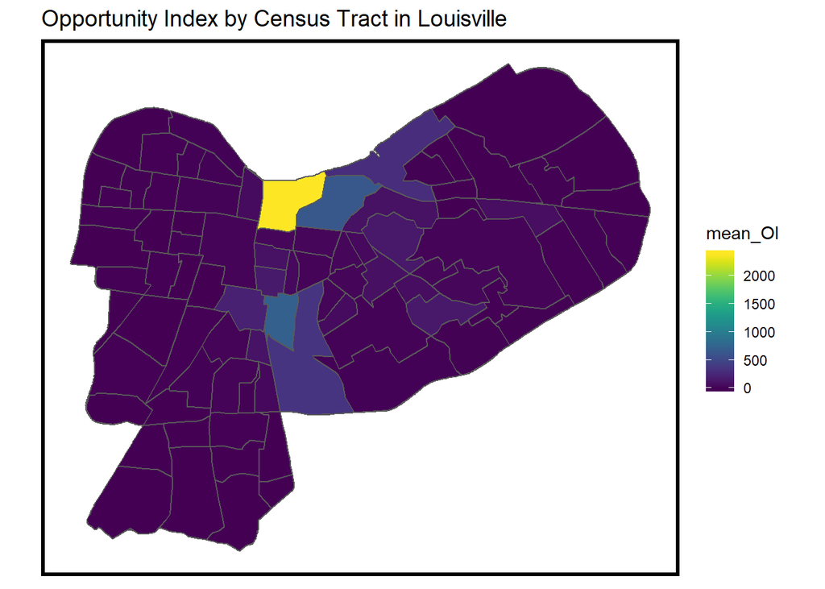

```r
ggplot() +
  geom_sf(data = LV_OI_bymonth %>% st_as_sf(), aes(fill = mean_OI)) +
  scale_fill_viridis() +
  mapTheme() +
  labs(title = "Opportunity Index by Census Tract in Louisville")
```

#### Net Scooter Flow

Net Scooter Flow is the Opportunity Index subtracted by User Trips Out.

`Net Scooter Flow = (Opportunity Index) - (User Trips Out)`

The below shows that the census tracts with the highest OI also have the highest Net Scooter Flow.

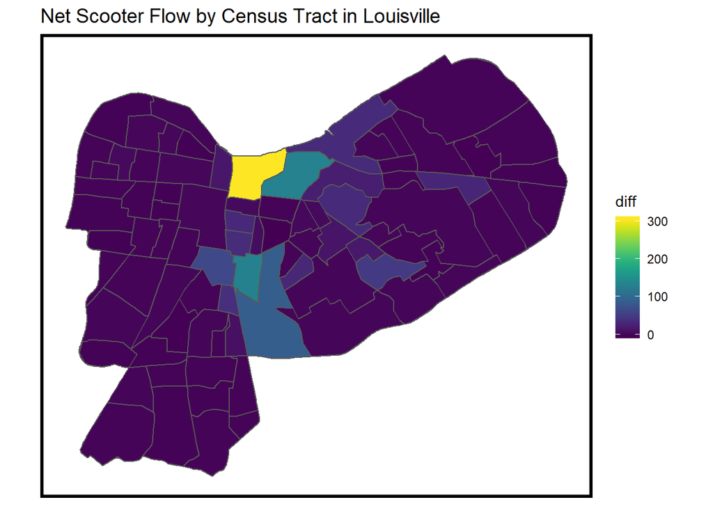

```r
ggplot() +
  geom_sf(data = LV_OI_bymonth %>% st_as_sf(), aes(fill = diff)) +
  scale_fill_viridis() +
  mapTheme() +
  labs(title = "Net Scooter Flow by Census Tract in Louisville")
```

## Census

Plot the census data for Louisville

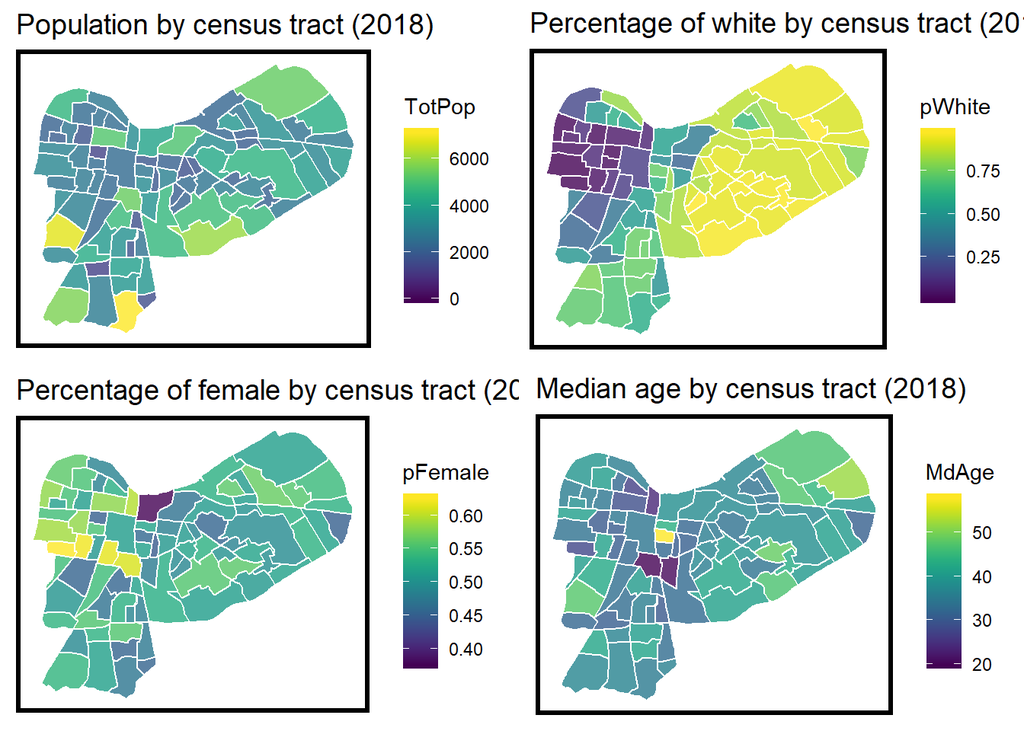

```r
grid.arrange(
# Population
ggplot() +
  geom_sf(data = LV_Census_ct, aes(fill = TotPop), color = "white", alpha = 0.8) +
  scale_fill_viridis()+
  labs(title = "Population by census tract (2018)") +
  mapTheme(),

# pWhite
ggplot() +
  geom_sf(data = LV_Census_ct, aes(fill = pWhite), color = "white", alpha = 0.8) +
  scale_fill_viridis()+
  labs(title = "Percentage of white by census tract (2018)") +
  mapTheme(),

#pFemale
ggplot() +
  geom_sf(data = LV_Census_ct, aes(fill = pFemale), color = "white", alpha = 0.8) +
  scale_fill_viridis()+
  labs(title = "Percentage of female by census tract (2018)") +
  mapTheme(),

# MdAge
ggplot() +
  geom_sf(data = LV_Census_ct, aes(fill = MdAge), color = "white", alpha = 0.8) +
  scale_fill_viridis()+
  labs(title = "Median age by census tract (2018)") +
  mapTheme(),

ncol = 2)
```

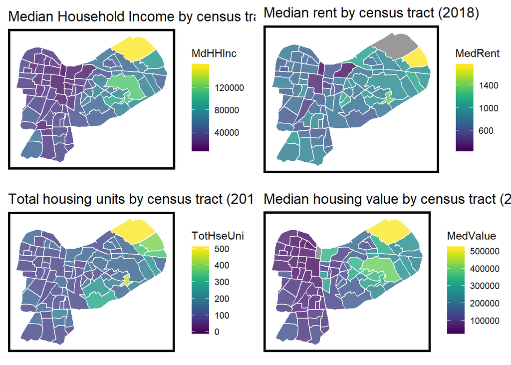

```r
grid.arrange(
# MdHHInc
ggplot() +
  geom_sf(data = LV_Census_ct, aes(fill = MdHHInc), color = "white", alpha = 0.8) +
  scale_fill_viridis()+
  labs(title = "Median Household Income by census tract (2018)") +
  mapTheme(),

# MedRent
ggplot() +
  geom_sf(data = LV_Census_ct, aes(fill = MedRent), color = "white", alpha = 0.8) +
  scale_fill_viridis()+
  labs(title = "Median rent by census tract (2018)") +
  mapTheme(),

# TotHseUni
ggplot() +
  geom_sf(data = LV_Census_ct, aes(fill = TotHseUni), color = "white", alpha = 0.8) +
  scale_fill_viridis()+
  labs(title = "Total housing units by census tract (2018)") +
  mapTheme(),

# MedValue
ggplot() +
  geom_sf(data = LV_Census_ct, aes(fill = MedValue), color = "white", alpha = 0.8) +
  scale_fill_viridis()+
  labs(title = "Median housing value by census tract (2018)") +
  mapTheme(),

ncol = 2)
```

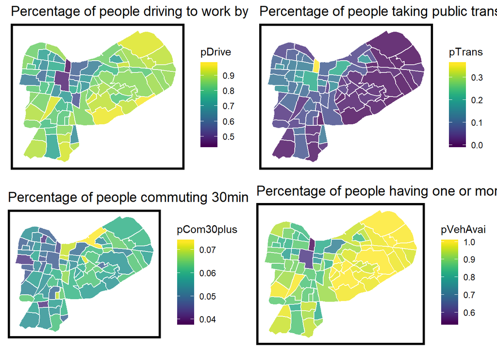

```r
grid.arrange(
#pDrive
ggplot() +
  geom_sf(data = LV_Census_ct, aes(fill = pDrive), color = "white", alpha = 0.8) +
  scale_fill_viridis()+
  labs(title = "Percentage of people driving to work by census tract (2018)") +
  mapTheme(),

#pTrans
ggplot() +
  geom_sf(data = LV_Census_ct, aes(fill = pTrans), color = "white", alpha = 0.8) +
  scale_fill_viridis()+
  labs(title = "Percentage of people taking public transit to work by census tract (2018)") +
  mapTheme(),

#pCom30plus
ggplot() +
  geom_sf(data = LV_Census_ct, aes(fill = pCom30plus), color = "white", alpha = 0.8) +
  scale_fill_viridis()+
  labs(title = "Percentage of people commuting 30mins or more by census tract (2018)") +
  mapTheme(),

#pVehAvai
ggplot() +
  geom_sf(data = LV_Census_ct, aes(fill = pVehAvai), color = "white", alpha = 0.8) +
  scale_fill_viridis()+
  labs(title = "Percentage of people having one or more vehicle available by census tract (2018)") +
  mapTheme(),

ncol = 2)
```

# Austin

## Read Data

```r
# Collect census data and geometries
AU_Census_raw <- get_acs(geography = "tract",
                         variables = census_vars,
                         year = 2018,
                         state = "TX",
                         geometry = TRUE,
                         county=c("Travis"),
                         output = "wide") %>%
  rename_census_cols %>%
  dplyr::select(GEOID,
                geometry,
                census_colNames) %>%
  st_transform(AU_proj)

AU_Census_geoinfo <- AU_Census_raw %>%
  dplyr::select(GEOID, geometry)
  # st_intersection(LV_SA %>% dplyr::select(geometry))

# extract centroid of each census tract
AU_Census_geoinfo <- AU_Census_geoinfo %>%
  mutate(centroid_X = st_coordinates(st_centroid(AU_Census_geoinfo))[, 1],
         centroid_Y = st_coordinates(st_centroid(AU_Census_geoinfo))[, 2])

AU_Census <- AU_Census_raw %>%
  mutate(pWhite = White_Pop / TotPop,
         Mean_Commute_Time = Total_Travel_Time / Num_Commuters,
         pTrans = Total_Public_Trans / Means_of_Transport_pop,
         pDrive = Total_cartruckvan/Means_of_Transport_pop,
         pFemale = TotFemale/TotPop,
         pCom30plus = (Travel_Time_3034 + Travel_Time_3539 + Travel_Time_4044 + Travel_Time_4559 +
                         Travel_Time_6089 + Travel_Time_90plus) / Total_Travel_Time,
         pOccupied = Occupied/Total_occupancy,
         pVehAvai = 1 - No_vehicle / Vehicle_own_pop)

# names(AU_Census)

AU_Census <- AU_Census %>%
  dplyr::select(GEOID, TotPop, TotHseUni, MdHHInc, MdAge, MedValue, MedRent, pWhite, Mean_Commute_Time,
                pTrans, pDrive, pFemale, pCom30plus, pOccupied, pVehAvai)
```

## Census

Plot the census data for Austin

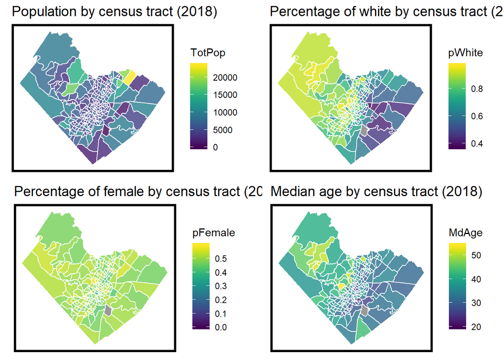

```r
grid.arrange(
# Population
ggplot() +
  geom_sf(data = AU_Census, aes(fill = TotPop), color = "white", alpha = 0.8) +
  scale_fill_viridis()+
  labs(title = "Population by census tract (2018)") +
  mapTheme(),

# pWhite
ggplot() +
  geom_sf(data = AU_Census, aes(fill = pWhite), color = "white", alpha = 0.8) +
  scale_fill_viridis()+
  labs(title = "Percentage of white by census tract (2018)") +
  mapTheme(),

#pFemale
ggplot() +
  geom_sf(data = AU_Census, aes(fill = pFemale), color = "white", alpha = 0.8) +
  scale_fill_viridis()+
  labs(title = "Percentage of female by census tract (2018)") +
  mapTheme(),

# MdAge
ggplot() +
  geom_sf(data = AU_Census, aes(fill = MdAge), color = "white", alpha = 0.8) +
  scale_fill_viridis()+
  labs(title = "Median age by census tract (2018)") +
  mapTheme(),

ncol = 2)
```

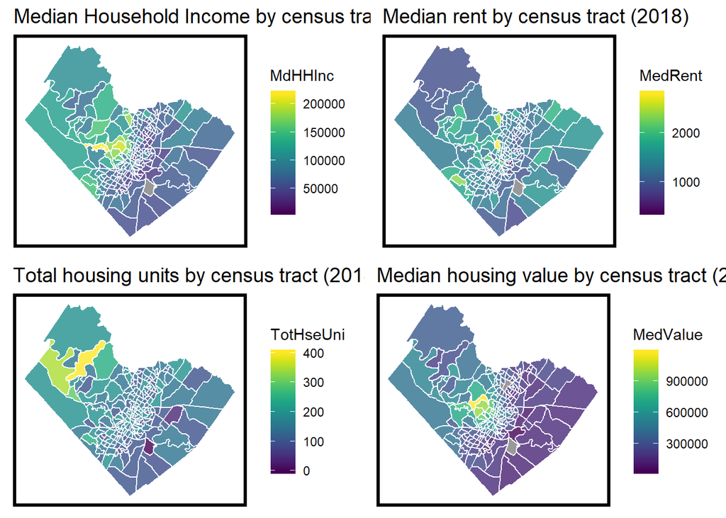

```r
grid.arrange(
# MdHHInc
ggplot() +
  geom_sf(data = AU_Census, aes(fill = MdHHInc), color = "white", alpha = 0.8) +
  scale_fill_viridis()+
  labs(title = "Median Household Income by census tract (2018)") +
  mapTheme(),

# MedRent
ggplot() +
  geom_sf(data = AU_Census, aes(fill = MedRent), color = "white", alpha = 0.8) +
  scale_fill_viridis()+
  labs(title = "Median rent by census tract (2018)") +
  mapTheme(),

# TotHseUni
ggplot() +
  geom_sf(data = AU_Census, aes(fill = TotHseUni), color = "white", alpha = 0.8) +
  scale_fill_viridis()+
  labs(title = "Total housing units by census tract (2018)") +
  mapTheme(),

# MedValue
ggplot() +
  geom_sf(data = AU_Census, aes(fill = MedValue), color = "white", alpha = 0.8) +
  scale_fill_viridis()+
  labs(title = "Median housing value by census tract (2018)") +
  mapTheme(),

ncol = 2)
```

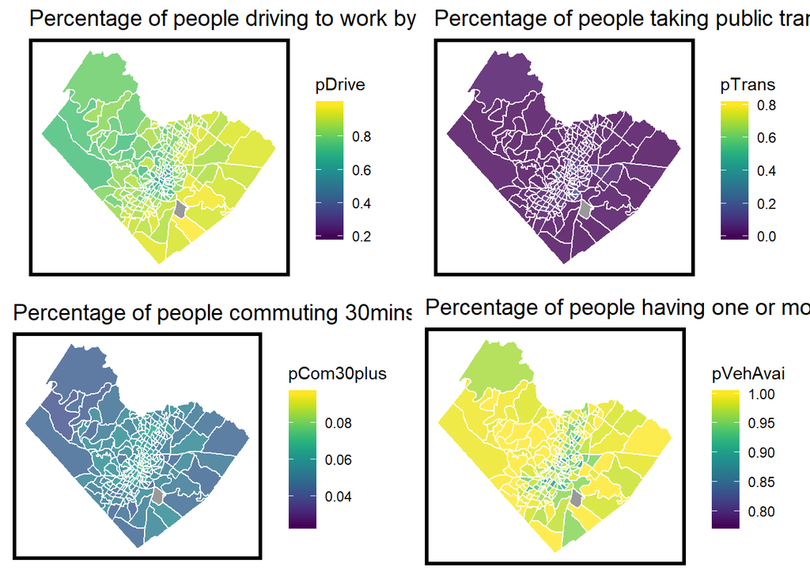

```r
grid.arrange(
#pDrive
ggplot() +
  geom_sf(data = AU_Census, aes(fill = pDrive), color = "white", alpha = 0.8) +
  scale_fill_viridis()+
  labs(title = "Percentage of people driving to work by census tract (2018)") +
  mapTheme(),

#pTrans
ggplot() +
  geom_sf(data = AU_Census, aes(fill = pTrans), color = "white", alpha = 0.8) +
  scale_fill_viridis()+
  labs(title = "Percentage of people taking public transit to work by census tract (2018)") +
  mapTheme(),

#pCom30plus
ggplot() +
  geom_sf(data = AU_Census, aes(fill = pCom30plus), color = "white", alpha = 0.8) +
  scale_fill_viridis()+
  labs(title = "Percentage of people commuting 30mins or more by census tract (2018)") +
  mapTheme(),

#pVehAvai
ggplot() +
  geom_sf(data = AU_Census, aes(fill = pVehAvai), color = "white", alpha = 0.8) +
  scale_fill_viridis()+
  labs(title = "Percentage of people having one or more vehicle available by census tract (2018)") +
  mapTheme(),

ncol = 2)
```

# DC

## Read Data

```r
# Collect census data and geometries
DC_Census_raw <- get_acs(geography = "tract",
                         variables = census_vars,
                         year = 2018,
                         state = "DC",
                         geometry = TRUE,
                         # county=c("Travis"),
                         output = "wide") %>%
  rename_census_cols %>%
  dplyr::select(GEOID,
                geometry,
                census_colNames) %>%
  st_transform(DC_proj)

DC_Census_geoinfo <- DC_Census_raw %>%
  dplyr::select(GEOID, geometry)

# extract centroid of each census tract
DC_Census_geoinfo <- DC_Census_geoinfo %>%
  mutate(centroid_X = st_coordinates(st_centroid(DC_Census_geoinfo))[, 1],
         centroid_Y = st_coordinates(st_centroid(DC_Census_geoinfo))[, 2])

DC_Census <- DC_Census_raw %>%
  mutate(pWhite = White_Pop / TotPop,
         Mean_Commute_Time = Total_Travel_Time / Num_Commuters,
         pTrans = Total_Public_Trans / Means_of_Transport_pop,
         pDrive = Total_cartruckvan/Means_of_Transport_pop,
         pFemale = TotFemale/TotPop,
         pCom30plus = (Travel_Time_3034 + Travel_Time_3539 + Travel_Time_4044 + Travel_Time_4559 +
                         Travel_Time_6089 + Travel_Time_90plus) / Total_Travel_Time,
         pOccupied = Occupied/Total_occupancy,
         pVehAvai = 1 - No_vehicle / Vehicle_own_pop)

# names(DC_Census)

DC_Census <- DC_Census %>%
  dplyr::select(GEOID, TotPop, TotHseUni, MdHHInc, MdAge, MedValue, MedRent, pWhite, Mean_Commute_Time,
                pTrans, pDrive, pFemale, pCom30plus, pOccupied, pVehAvai)
```

## Census

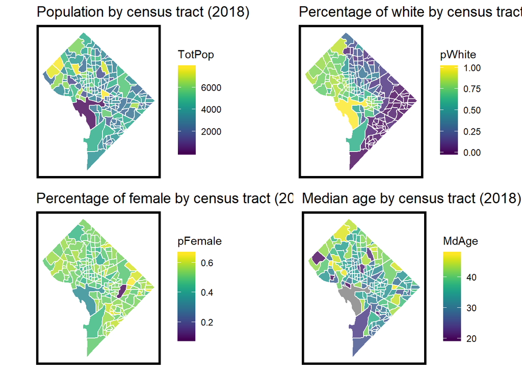

```r
grid.arrange(
# Population
ggplot() +
  geom_sf(data = DC_Census, aes(fill = TotPop), color = "white", alpha = 0.8) +
  scale_fill_viridis()+
  labs(title = "Population by census tract (2018)") +
  mapTheme(),

# pWhite
ggplot() +
  geom_sf(data = DC_Census, aes(fill = pWhite), color = "white", alpha = 0.8) +
  scale_fill_viridis()+
  labs(title = "Percentage of white by census tract (2018)") +
  mapTheme(),

#pFemale
ggplot() +
  geom_sf(data = DC_Census, aes(fill = pFemale), color = "white", alpha = 0.8) +
  scale_fill_viridis()+
  labs(title = "Percentage of female by census tract (2018)") +
  mapTheme(),

# MdAge
ggplot() +
  geom_sf(data = DC_Census, aes(fill = MdAge), color = "white", alpha = 0.8) +
  scale_fill_viridis()+
  labs(title = "Median age by census tract (2018)") +
  mapTheme(),

ncol = 2)
```

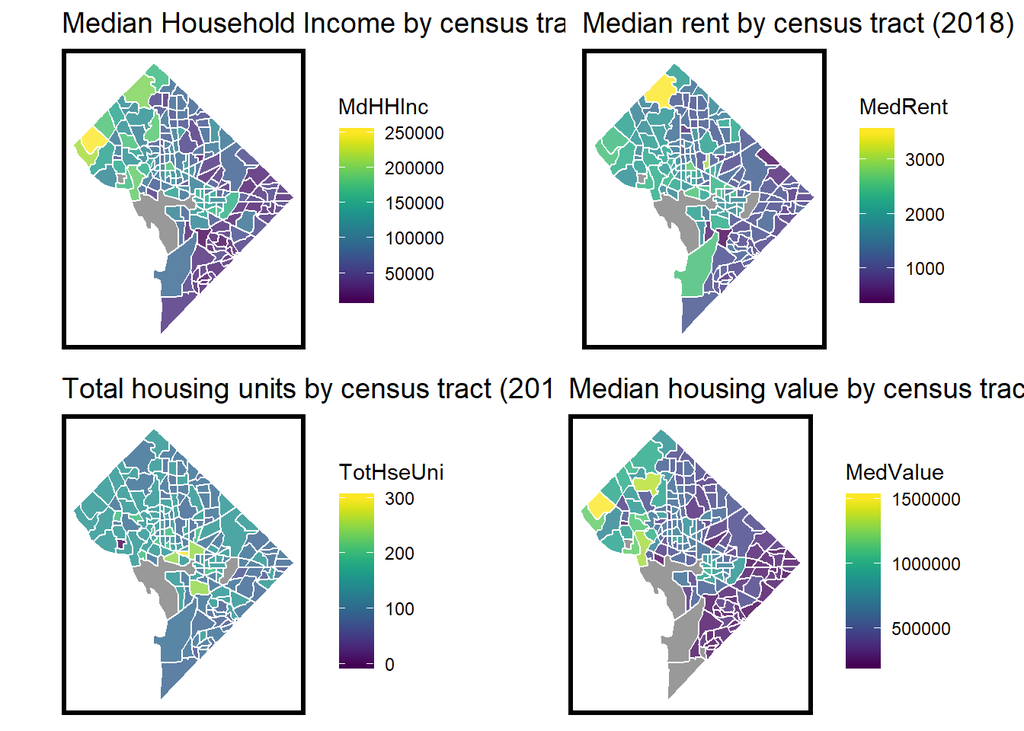

```r
grid.arrange(
# MdHHInc
ggplot() +
  geom_sf(data = DC_Census, aes(fill = MdHHInc), color = "white", alpha = 0.8) +
  scale_fill_viridis()+
  labs(title = "Median Household Income by census tract (2018)") +
  mapTheme(),

# MedRent
ggplot() +
  geom_sf(data = DC_Census, aes(fill = MedRent), color = "white", alpha = 0.8) +
  scale_fill_viridis()+
  labs(title = "Median rent by census tract (2018)") +
  mapTheme(),

# TotHseUni
ggplot() +
  geom_sf(data = DC_Census, aes(fill = TotHseUni), color = "white", alpha = 0.8) +
  scale_fill_viridis()+
  labs(title = "Total housing units by census tract (2018)") +
  mapTheme(),

# MedValue
ggplot() +
  geom_sf(data = DC_Census, aes(fill = MedValue), color = "white", alpha = 0.8) +
  scale_fill_viridis()+
  labs(title = "Median housing value by census tract (2018)") +
  mapTheme(),

ncol = 2)
```

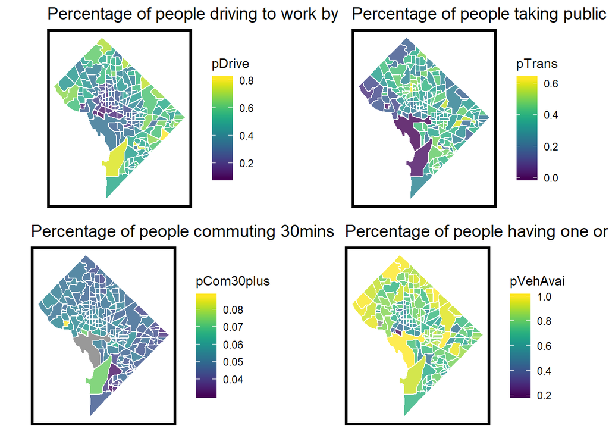

```r
grid.arrange(
#pDrive
ggplot() +
  geom_sf(data = DC_Census, aes(fill = pDrive), color = "white", alpha = 0.8) +
  scale_fill_viridis()+
  labs(title = "Percentage of people driving to work by census tract (2018)") +
  mapTheme(),

#pTrans
ggplot() +
  geom_sf(data = DC_Census, aes(fill = pTrans), color = "white", alpha = 0.8) +
  scale_fill_viridis()+
  labs(title = "Percentage of people taking public transit to work by census tract (2018)") +
  mapTheme(),

#pCom30plus
ggplot() +
  geom_sf(data = DC_Census, aes(fill = pCom30plus), color = "white", alpha = 0.8) +
  scale_fill_viridis()+
  labs(title = "Percentage of people commuting 30mins or more by census tract (2018)") +
  mapTheme(),

#pVehAvai
ggplot() +
  geom_sf(data = DC_Census, aes(fill = pVehAvai), color = "white", alpha = 0.8) +
  scale_fill_viridis()+
  labs(title = "Percentage of people having one or more vehicle available by census tract (2018)") +
  mapTheme(),

ncol = 2)
```

# KC

## Read Data

```r
# Collect census data and geometries
KC_Census_raw1 <- get_acs(geography = "tract",
                         variables = census_vars,
                         year = 2018,
                         state = "MO",
                         geometry = TRUE,
                         county=c("Jackson"),
                         output = "wide") %>%
  rename_census_cols %>%
  dplyr::select(GEOID,
                geometry,
                census_colNames) %>%
  st_transform(KC_proj)

KC_Census_raw2 <- get_acs(geography = "tract",
                         variables = census_vars,
                         year = 2018,
                         state = "MO",
                         geometry = TRUE,
                         county=c("Johnson"),
                         output = "wide") %>%
  rename_census_cols %>%
  dplyr::select(GEOID,
                geometry,
                census_colNames) %>%
  st_transform(KC_proj)

KC_Census_raw <- rbind(KC_Census_raw1, KC_Census_raw2)

KC_Census_geoinfo <- KC_Census_raw %>%
  dplyr::select(GEOID, geometry)
# st_intersection(LV_SA %>% dplyr::select(geometry))

# extract centroid of each census tract
KC_Census_geoinfo <- KC_Census_geoinfo %>%
  mutate(centroid_X = st_coordinates(st_centroid(KC_Census_geoinfo))[, 1],
         centroid_Y = st_coordinates(st_centroid(KC_Census_geoinfo))[, 2])

KC_Census <- KC_Census_raw %>%
  mutate(pWhite = White_Pop / TotPop,
         Mean_Commute_Time = Total_Travel_Time / Num_Commuters,
         pTrans = Total_Public_Trans / Means_of_Transport_pop,
         pDrive = Total_cartruckvan/Means_of_Transport_pop,
         pFemale = TotFemale/TotPop,
         pCom30plus = (Travel_Time_3034 + Travel_Time_3539 + Travel_Time_4044 + Travel_Time_4559 +
                         Travel_Time_6089 + Travel_Time_90plus) / Total_Travel_Time,
         pOccupied = Occupied/Total_occupancy,
         pVehAvai = 1 - No_vehicle / Vehicle_own_pop)

# names(KC_Census)

KC_Census <- KC_Census %>%
  dplyr::select(GEOID, TotPop, TotHseUni, MdHHInc, MdAge, MedValue, MedRent, pWhite, Mean_Commute_Time,
                pTrans, pDrive, pFemale, pCom30plus, pOccupied, pVehAvai)
```

## Census

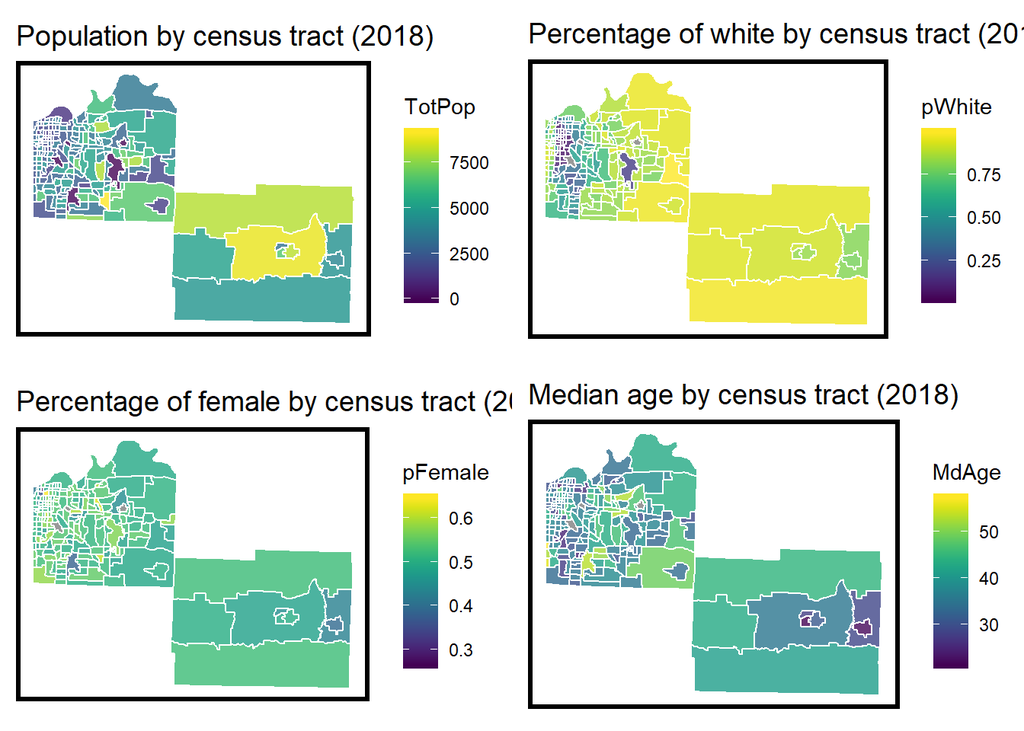

```r
grid.arrange(
# Population
ggplot() +
  geom_sf(data = KC_Census, aes(fill = TotPop), color = "white", alpha = 0.8) +
  scale_fill_viridis()+
  labs(title = "Population by census tract (2018)") +
  mapTheme(),

# pWhite
ggplot() +
  geom_sf(data = KC_Census, aes(fill = pWhite), color = "white", alpha = 0.8) +
  scale_fill_viridis()+
  labs(title = "Percentage of white by census tract (2018)") +
  mapTheme(),

#pFemale
ggplot() +
  geom_sf(data = KC_Census, aes(fill = pFemale), color = "white", alpha = 0.8) +
  scale_fill_viridis()+
  labs(title = "Percentage of female by census tract (2018)") +
  mapTheme(),

# MdAge
ggplot() +
  geom_sf(data = KC_Census, aes(fill = MdAge), color = "white", alpha = 0.8) +
  scale_fill_viridis()+
  labs(title = "Median age by census tract (2018)") +
  mapTheme(),

ncol = 2)
```

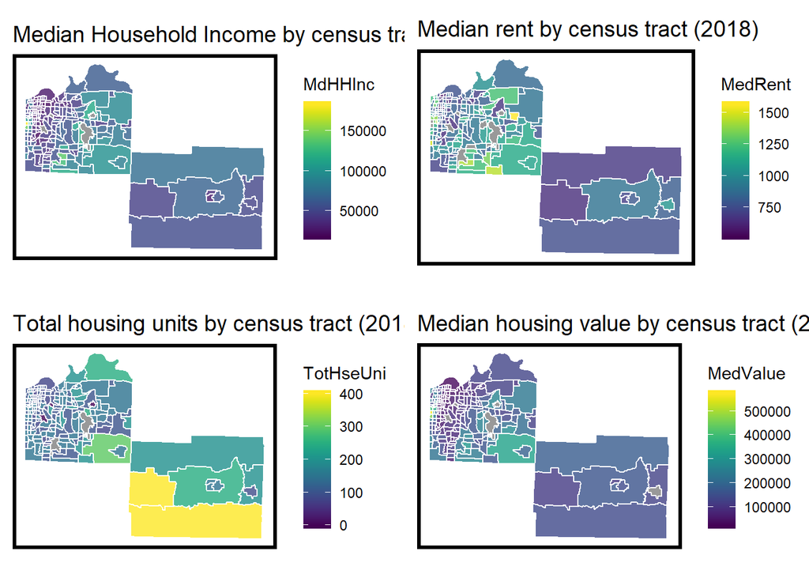

```r
grid.arrange(
# MdHHInc
ggplot() +
  geom_sf(data = KC_Census, aes(fill = MdHHInc), color = "white", alpha = 0.8) +
  scale_fill_viridis()+
  labs(title = "Median Household Income by census tract (2018)") +
  mapTheme(),

# MedRent
ggplot() +
  geom_sf(data = KC_Census, aes(fill = MedRent), color = "white", alpha = 0.8) +
  scale_fill_viridis()+
  labs(title = "Median rent by census tract (2018)") +
  mapTheme(),

# TotHseUni
ggplot() +
  geom_sf(data = KC_Census, aes(fill = TotHseUni), color = "white", alpha = 0.8) +
  scale_fill_viridis()+
  labs(title = "Total housing units by census tract (2018)") +
  mapTheme(),

# MedValue
ggplot() +
  geom_sf(data = KC_Census, aes(fill = MedValue), color = "white", alpha = 0.8) +
  scale_fill_viridis()+
  labs(title = "Median housing value by census tract (2018)") +
  mapTheme(),

ncol = 2)
```

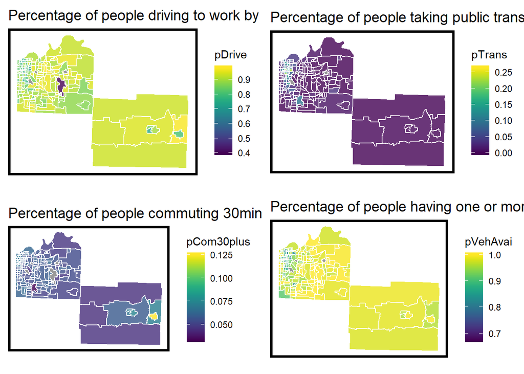

```r
grid.arrange(
#pDrive
ggplot() +
  geom_sf(data = KC_Census, aes(fill = pDrive), color = "white", alpha = 0.8) +
  scale_fill_viridis()+
  labs(title = "Percentage of people driving to work by census tract (2018)") +
  mapTheme(),

#pTrans
ggplot() +
  geom_sf(data = KC_Census, aes(fill = pTrans), color = "white", alpha = 0.8) +
  scale_fill_viridis()+
  labs(title = "Percentage of people taking public transit to work by census tract (2018)") +
  mapTheme(),

#pCom30plus
ggplot() +
  geom_sf(data = KC_Census, aes(fill = pCom30plus), color = "white", alpha = 0.8) +
  scale_fill_viridis()+
  labs(title = "Percentage of people commuting 30mins or more by census tract (2018)") +
  mapTheme(),

#pVehAvai
ggplot() +
  geom_sf(data = KC_Census, aes(fill = pVehAvai), color = "white", alpha = 0.8) +
  scale_fill_viridis()+
  labs(title = "Percentage of people having one or more vehicle available by census tract (2018)") +
  mapTheme(),

ncol = 2)
```

# MNP

## Read Data

```r
# Set directory for DC data
MNP_directory <- paste(data_directory,
                      "/MNP",
                      sep = "")

# List of all scooter-related files
MNP_scooter_trip_list <- list.files(path = MNP_directory, pattern = "*.csv", full.names = T)

MNP_scooter_trip_list
MNP_scooter_data_raw <- MNP_scooter_trip_list %>%
  map_df(.,
         ~ read_csv(.,
                    col_types = cols(.default = "c")) %>% # read all the columns as characters for simplicity
           set_names(., tolower(names(.))) %>%
           mutate(dataset = .x,
                  dataset = str_match(dataset, paste(MNP_directory, "(.*?)", "\\.csv", sep = ""))[, 2]))

# Change the stattime and endtime to datetime object
MNP_scooter_data_raw$starttime <- as_datetime(MNP_scooter_data_raw$starttime)
MNP_scooter_data_raw$endtime <- as_datetime(MNP_scooter_data_raw$endtime)

MNP_scooter_data_raw <- MNP_scooter_data_raw %>%
  dplyr::select(-objectid)

# Read street centerline shapefile
MNP_ST_file <- file.path(MNP_directory,
                         "PW_Street_Centerline/PW_Street_Centerline.shp")

MNP_street <- st_read(MNP_ST_file) %>%
  st_transform(MNP_proj)

# Read city boundary shapefile
MNP_ct_file <- file.path(MNP_directory,
                         "MNP_CityLimits/msvcGIS_MinneapolisCityLimits.shp")

MNP_ct <- st_read(MNP_ct_file) %>%
  st_transform(MNP_proj)

# Collect census data and geometries
MNP_Census_raw <- get_acs(geography = "tract",
                         variables = census_vars,
                         year = 2018,
                         state = "MN",
                         geometry = TRUE,
                         county = c("Hennepin"),
                         output = "wide") %>%
  rename_census_cols %>%
  dplyr::select(GEOID,
                geometry,
                census_colNames) %>%
  st_transform(MNP_proj)

MNP_Census_geoinfo <- MNP_Census_raw %>%
  dplyr::select(GEOID, geometry) %>%
  st_intersection(MNP_ct %>% dplyr::select(geometry))

# extract centroid of each census tract
MNP_Census_geoinfo <- MNP_Census_geoinfo %>%
  mutate(centroid_X = st_coordinates(st_centroid(MNP_Census_geoinfo))[, 1],
         centroid_Y = st_coordinates(st_centroid(MNP_Census_geoinfo))[, 2])

MNP_Census <- MNP_Census_raw %>%
  mutate(pWhite = White_Pop / TotPop,
         Mean_Commute_Time = Total_Travel_Time / Num_Commuters,
         pTrans = Total_Public_Trans / Means_of_Transport_pop,
         pDrive = Total_cartruckvan/Means_of_Transport_pop,
         pFemale = TotFemale/TotPop,
         pCom30plus = (Travel_Time_3034 + Travel_Time_3539 + Travel_Time_4044 + Travel_Time_4559 +
                         Travel_Time_6089 + Travel_Time_90plus) / Total_Travel_Time,
         pOccupied = Occupied/Total_occupancy,
         pVehAvai = 1 - No_vehicle / Vehicle_own_pop)

# names(MNP_Census)

MNP_Census <- MNP_Census %>%
  dplyr::select(GEOID, TotPop, TotHseUni, MdHHInc, MdAge, MedValue, MedRent, pWhite, Mean_Commute_Time,
                pTrans, pDrive, pFemale, pCom30plus, pOccupied, pVehAvai)

MNP_tract_list <- MNP_Census_geoinfo$GEOID

MNP_Census_ct <- MNP_Census %>%
  filter(MNP_Census$GEOID %in% MNP_tract_list) %>%
  st_set_geometry(NULL)

# rejoin geometry infor from ct_LV
MNP_Census_ct <- merge(MNP_Census_geoinfo, MNP_Census_ct, by = 'GEOID')
```

## Census

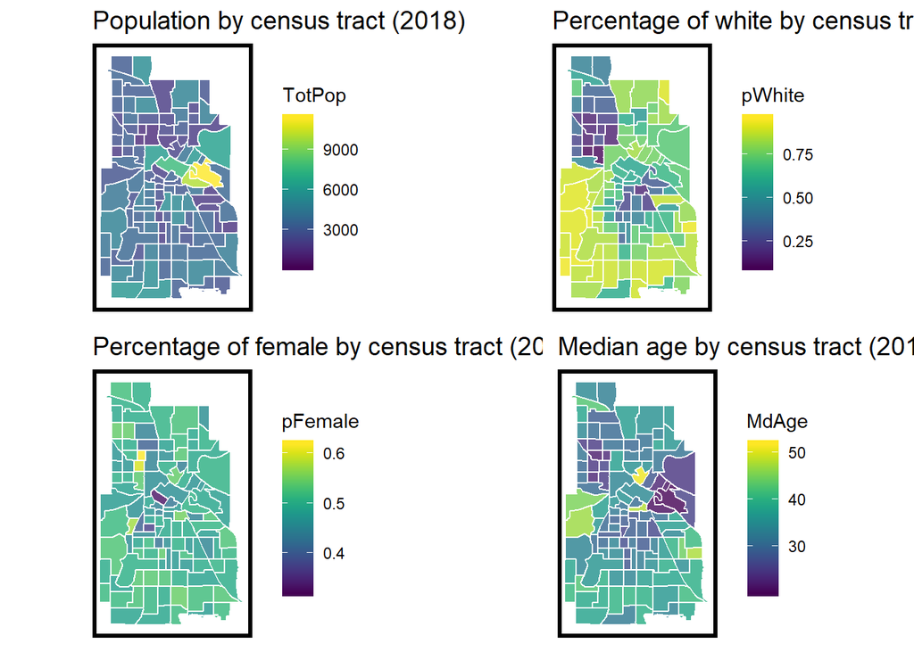

```r
grid.arrange(
  # Population
  ggplot() +
    geom_sf(data = MNP_Census_ct, aes(fill = TotPop), color = "white", alpha = 0.8) +
    scale_fill_viridis()+
    labs(title = "Population by census tract (2018)") +
    mapTheme(),

  # pWhite
  ggplot() +
    geom_sf(data = MNP_Census_ct, aes(fill = pWhite), color = "white", alpha = 0.8) +
    scale_fill_viridis()+
    labs(title = "Percentage of white by census tract (2018)") +
    mapTheme(),

  #pFemale
  ggplot() +
    geom_sf(data = MNP_Census_ct, aes(fill = pFemale), color = "white", alpha = 0.8) +
    scale_fill_viridis()+
    labs(title = "Percentage of female by census tract (2018)") +
    mapTheme(),

  # MdAge
  ggplot() +
    geom_sf(data = MNP_Census_ct, aes(fill = MdAge), color = "white", alpha = 0.8) +
    scale_fill_viridis()+
    labs(title = "Median age by census tract (2018)") +
    mapTheme(),

  ncol = 2)
```

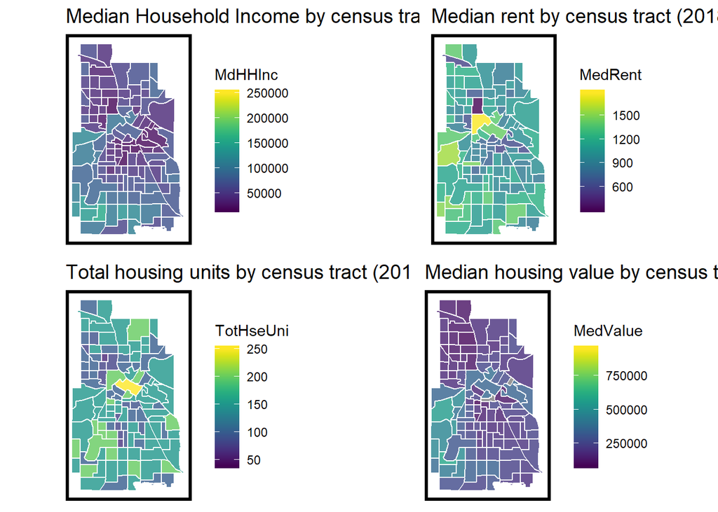

```r
grid.arrange(
  # MdHHInc
  ggplot() +
    geom_sf(data = MNP_Census_ct, aes(fill = MdHHInc), color = "white", alpha = 0.8) +
    scale_fill_viridis()+
    labs(title = "Median Household Income by census tract (2018)") +
    mapTheme(),

  # MedRent
  ggplot() +
    geom_sf(data = MNP_Census_ct, aes(fill = MedRent), color = "white", alpha = 0.8) +
    scale_fill_viridis()+
    labs(title = "Median rent by census tract (2018)") +
    mapTheme(),

  # TotHseUni
  ggplot() +
    geom_sf(data = MNP_Census_ct, aes(fill = TotHseUni), color = "white", alpha = 0.8) +
    scale_fill_viridis()+
    labs(title = "Total housing units by census tract (2018)") +
    mapTheme(),

  # MedValue
  ggplot() +
    geom_sf(data = MNP_Census_ct, aes(fill = MedValue), color = "white", alpha = 0.8) +
    scale_fill_viridis()+
    labs(title = "Median housing value by census tract (2018)") +
    mapTheme(),

  ncol = 2)
```

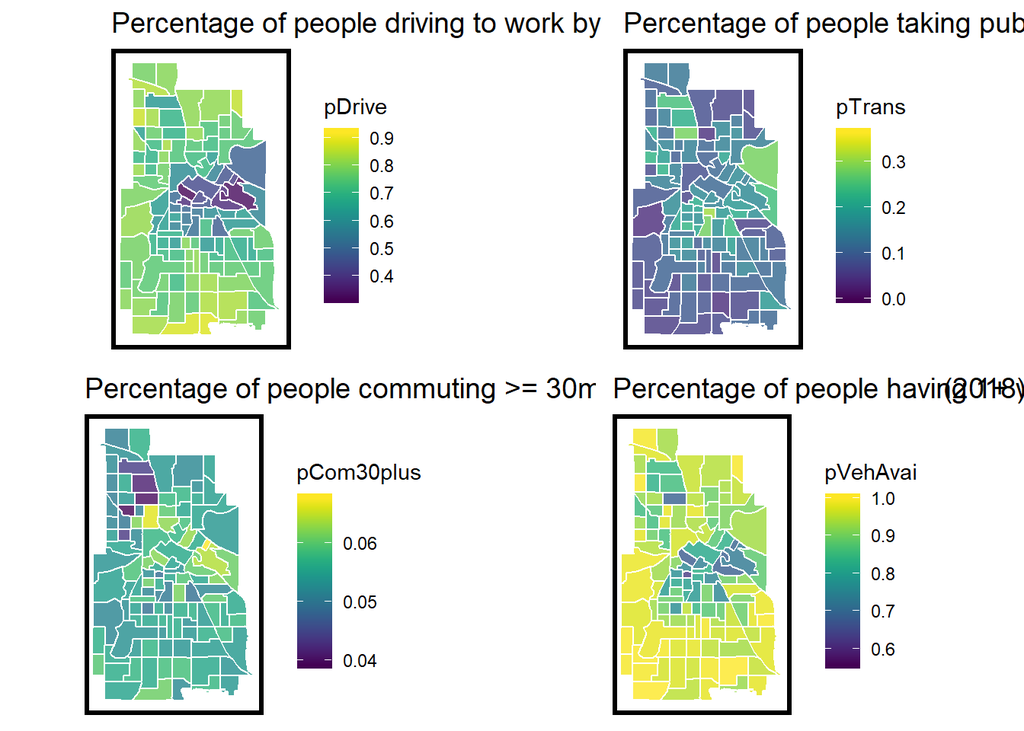

```r
grid.arrange(
  #pDrive
  ggplot() +
    geom_sf(data = MNP_Census_ct, aes(fill = pDrive), color = "white", alpha = 0.8) +
    scale_fill_viridis()+
    labs(title = "Percentage of people driving to work by census tract (2018)") +
    mapTheme(),

  #pTrans
  ggplot() +
    geom_sf(data = MNP_Census_ct, aes(fill = pTrans), color = "white", alpha = 0.8) +
    scale_fill_viridis()+
    labs(title = "Percentage of people taking public transit to work by census tract (2018)") +
    mapTheme(),

  #pCom30plus
  ggplot() +
    geom_sf(data = MNP_Census_ct, aes(fill = pCom30plus), color = "white", alpha = 0.8) +
    scale_fill_viridis()+
    labs(title = "Percentage of people commuting >= 30mins or more by census tract (2018)") +
    mapTheme(),

  #pVehAvai
  ggplot() +
    geom_sf(data = MNP_Census_ct, aes(fill = pVehAvai), color = "white", alpha = 0.8) +
    scale_fill_viridis()+
    labs(title = "Percentage of people having 1+ vehicle available by census tract 2018") +
    mapTheme(),

  ncol = 2)
```

# All Cities

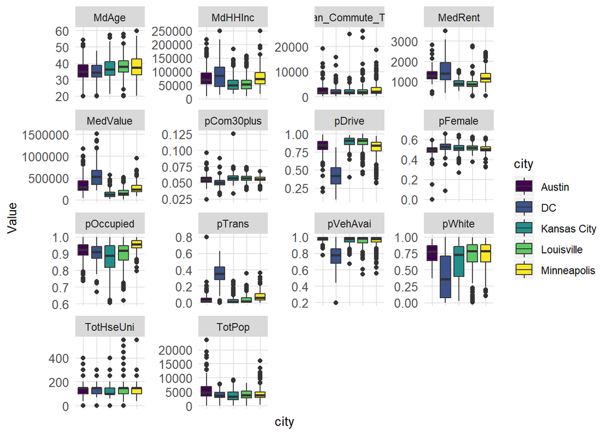

```r
AU_Census$city <- 'Austin'
KC_Census$city <- 'Kansas City'
LV_Census$city <- 'Louisville'
MNP_Census$city <- 'Minneapolis'
DC_Census$city <- 'DC'

AU_KC_LV_MNP_DC_Census <- rbind(AU_Census %>% st_set_geometry(NULL),
                         KC_Census %>% st_set_geometry(NULL),
                         LV_Census %>% st_set_geometry(NULL),
                         MNP_Census %>% st_set_geometry(NULL),
                         DC_Census %>% st_set_geometry(NULL))

AU_KC_LV_MNP_DC_Census_gather <- AU_KC_LV_MNP_DC_Census %>%
  dplyr::select(-GEOID) %>%
  gather(key='Variable',"Value", -city)

ggplot() +
  geom_boxplot(data = as.data.frame(AU_KC_LV_MNP_DC_Census_gather), aes(x=city, y=Value, fill=city)) +
  scale_fill_viridis(discrete = T)+
  facet_wrap(~Variable, ncol = 4, scales = "free") +
  #labs(title = "Price as a function of continuous variables") +
  theme(axis.text.x = element_blank(), legend.position = 'right', axis.text.x.bottom = element_blank()) +
  plotTheme
```

# Appendix

## Full Louisville Rebalancing Policy

For reference, the full policy is linked and summarized below:

[Link to policy](https://data.louisvilleky.gov/sites/default/files/Dockless_Policy_7_12_2019.pdf)

- Vehicle Limits
  - General
    - A total of 8 operators will be permitted to operate within Metro designated operational zones.
    - Fleet increases subject to general compliance with all policy provisions
    - Calculations for assessing fleet size increases shall follow this formula: `rides per vehicle per day = total rides / total permitted vehicles`
  - For Full-Operating Permit Holders
    - Operators may apply for possible incremental increases of 200 vehicles per month provided that:
      1. Ridership exceeds 3 rides per vehicle per day on vehicles owned by that operator.
      2. Issues identified by Metro are being adequately addressed to Metro’s satisfaction
    - A cap of 1,050 vehicles applies to each operator.
    - Fleet Reductions:
      1. If ridership falls below an average of 2 rides per vehicle per day in the preceding month, the operator must remove vehicles from service. The specific number of vehicles to be removed will be determined by Metro based upon the available data and contributing factors (seasonal shifts, etc.).
    - Cap Extensions
      1. Vehicle caps may be raised at the discretion of Metro. Considerations factoring into raising the caps are as follows:
         - Ridership exceeds 5 rides per vehicle per day on average over the preceding month.
         - Issues identified by Metro are being adequately addressed to Metro’s satisfaction.
  - Current Limits
    - Bird - 450 max vehicles/day - launched August 2018 (*According to the data, they launch in August 2019*)
    - Lime - 450 max vehicles/day - launched November 2018
    - Bolt - 150 max vehicles/day - launched July 2019
    - Spin - 150 max vehicles/day - launched August 2019
- Distribution Requirements >To ensure access to shared mobility transportation options throughout the community, Metro has established distribution zones. Distribution zones are intended to ensure that no singular zone is intentionally over-served or under-served. Operators must comply with distributional requirements. Failure to comply with this provision constitutes a breach of the license and may result in the assessment of fleet size reductions, suspension, or even termination of the license. The duration of any suspension shall be at the sole discretion of Metro but will be no less than 6 months. Terminations shall apply for 1 year.
  - For operators with 150 permitted vehicles or fewer, there are no distributional requirements.
    - For operators with permitted fleets ranging in size between 150 and 350 vehicles, 20% of each operator’s vehicles must be located within zones 1 and 9.
    - Distribution plans within Zones 1 and 9 must be submitted to Metro for approval to ensure adequate accessibility for residents of each zone has been achieved.
    - For fleets ranging in size between 350 and 1050 vehicles, 20% of each operator’s vehicles must be located within zones 1 and 9 and 10% must be in zone 8.
    - Distribution plans within Zones 1, 8, and 9 must be submitted to Metro for approval to ensure adequate accessibility for residents of each zone has been achieved.